# Case Study for suicide Rate

**Questions:**

- Is the suicide rate more prominent in some age categories than others?
- Which countries have the most and the least number of suicides?
- What is the effect of the population on suicide rates?
- What is the effect of the GDP of a country on suicide rates?
- What is the trend of suicide rates across all the years?
- Is there a difference between the suicide rates of men and women?

# First import dataset and all libraries

```python
import warnings
warnings.filterwarnings('ignore')
```

```python
import numpy as np
import pandas as pd
import matplotlib.pyplot as plt
import seaborn as sns
sns.set_style('darkgrid')
```

```python
masterdf = pd.read_csv('master.csv')
masterdf.describe()
```

|  | year | suicides_no | population | suicides/100k pop | HDI for year | gdp_per_capita ($) |
| --- | --- | --- | --- | --- | --- | --- |
| count | 27820.000000 | 27820.000000 | 2.782000e+04 | 27820.000000 | 8364.000000 | 27820.000000 |
| mean | 2001.258375 | 242.574407 | 1.844794e+06 | 12.816097 | 0.776601 | 16866.464414 |
| std | 8.469055 | 902.047917 | 3.911779e+06 | 18.961511 | 0.093367 | 18887.576472 |
| min | 1985.000000 | 0.000000 | 2.780000e+02 | 0.000000 | 0.483000 | 251.000000 |
| 25% | 1995.000000 | 3.000000 | 9.749850e+04 | 0.920000 | 0.713000 | 3447.000000 |
| 50% | 2002.000000 | 25.000000 | 4.301500e+05 | 5.990000 | 0.779000 | 9372.000000 |
| 75% | 2008.000000 | 131.000000 | 1.486143e+06 | 16.620000 | 0.855000 | 24874.000000 |
| max | 2016.000000 | 22338.000000 | 4.380521e+07 | 224.970000 | 0.944000 | 126352.000000 |

# 1. Is the suicide rate more prominent in some age categories than others

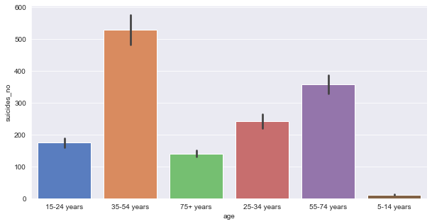

```python
plt.figure(figsize=(10,5))
ageVsSuicideNum = sns.barplot(x='age', y='suicides_no', data=masterdf, palette='muted')
```

# In the following graph we can see 35-54 years are the more prominent age categories

# 2. Which countries have the most and the least number of suicides?

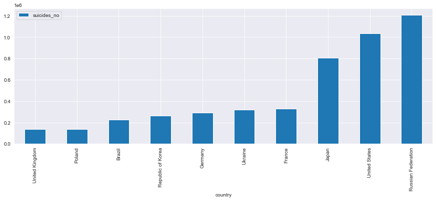

```python
masterdf.groupby(by=['country'])['suicides_no'].sum().reset_index().sort_values(['suicides_no']).tail(10).plot(x='country',
                                                                                                           y='suicides_no',
                                                                                                           kind='bar',
                                                                                                           figsize=(15,5))
plt.show()
```

# As we can see from this graph, the highest amount of suicides numerically is in the Russian Federation

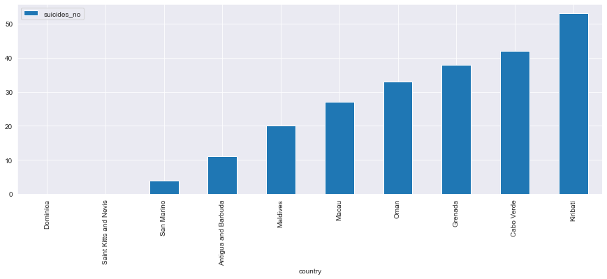

```python
masterdf.groupby(by=['country'])['suicides_no'].sum().reset_index().sort_values(['suicides_no']).head(10).plot(x='country',
                                                                                                           y='suicides_no',
                                                                                                           kind='bar',
                                                                                                           figsize=(15,5))
plt.show()
```